# Boxplots with ggplot

Sue McClatchy

Aug 1, 2016

## Learning Objectives

> - Load data from a URL.
> - Describe the anatomy of a box plot.
> - Use box plots to compare mean and median values between groups.
> - Order groups by mean value.
> - Subset data.
> - Describe some pitfalls of using bar charts to display or compare means.

## Preliminaries

Bar charts are useful for displaying count data, for example, but are often used to portray statistical information that they don’t represent well. In this lesson we’ll learn to [‘Kick the bar chart habit’](http://www.nature.com/nmeth/journal/v11/n2/full/nmeth.2837.html) by creating box plots as an alternative to bar charts. This lesson uses data from a multi-system survey of mouse physiology in 8 inbred founder strains and 54 F1 hybrids of the Collaborative Cross. The study is described in [Lenarcic et al, 2012](http://www.genetics.org/content/190/2/413.full). For more information about this data set, see the [CGDpheno3 data](http://phenome.jax.org/db/q?rtn=projects/details&id=439) at Mouse Phenome Database.

#### Load packages and libraries

```r
install.packages("ggplot2")
```

You only need to install a package once to download it into your machine’s library. Once you have installed the package on your machine, you need to load the library in order to use the functions contained in the package.

```r
library(ggplot2)
```

When you load a library you’ll get a warning message indicating the R version in which the library was built. If it’s different from the R version that you’re running, you might occasionally run into problems depending on the library and the functions it contains. To find out what version of R you have, type

```r
version
```

```
               _
platform       x86_64-apple-darwin13.4.0
arch           x86_64
os             darwin13.4.0
system         x86_64, darwin13.4.0
status
major          3
minor          3.1
year           2016
month          06
day            21
svn rev        70800
language       R
version.string R version 3.3.1 (2016-06-21)
nickname       Bug in Your Hair
```

The version of R is given as version.string, followed by the nickname for the version.

#### Load data

Load the data from this shortened URL. Mind the double quotes.

```r
cc_data <- read.csv(file = "http://bit.ly/CGDpheno3")
```

#### Explore data

Explore the data variables. The first 4 columns contain strain, sex, and ID numbers. The remaining contain phenotype measurements with abbreviated names.

```r
names(cc_data)
```

```
 [1] "strain"          "sex"             "id"
 [4] "mouse_num"       "CHOL"            "HDL"
 [7] "GLU"             "TG"              "WBC"
[10] "pctLYMP"         "pctNEUT"         "pctMONO"
[13] "pctBASO"         "pctEOS"          "pctLUC"
[16] "RBC"             "pctRetic"        "RDW"
[19] "MCH"             "MCHC"            "CHCM"
[22] "HDW"             "MCV"             "cHGB"
[25] "mHGB"            "HCT"             "PLT"
[28] "MPV"             "pulse"           "pulse_std"
[31] "systolic_BP"     "systolic_BP_std" "CV"
[34] "HR"              "HRV"             "R_amplitude"
[37] "RS_amplitude"    "N"               "PQ"
[40] "PR"              "QRS"             "QT"
[43] "QT_dispersion"   "QTc"             "QTc_dispersion"
[46] "RR"              "ST"              "BMC"
[49] "BMD"             "bone_area"       "total_area"
[52] "LTM"             "pct_fat"         "TTM"
[55] "bw"
```

How many mice?

```r
dim(cc_data)
```

```
[1] 642  55
```

How many mice of each sex?

```r
table(cc_data$sex)
```

```
  f   m
321 321
```

How many mice of each strain?

```r
table(cc_data$strain)
```

```
129S1/SvImJ     129SAF1    129SB6F1  129SCASTF1   129SNODF1
         10          10          10          10           5
  129SNZOF1   129SPWKF1   129SWSBF1         A/J     A129SF1
         21          10          10          10          10
      AB6F1     ACASTF1      ANODF1      ANZOF1      APWKF1
         10          10          10          10          10
     AWSBF1  B6129SF1/J     B6AF1/J    B6CASTF1     B6NODF1
         10          10          10          10          10
    B6NZOF1     B6PWKF1     B6WSBF1    C57BL/6J    CAST/EiJ
         10          11          10          10          11
 CAST129SF1     CASTAF1    CASTB6F1   CASTNODF1   CASTNZOF1
         10          10          10          10          10
  CASTPWKF1   CASTWSBF1  NOD/ShiLtJ   NOD129SF1      NODAF1
         10          10          10          10          10
    NODB6F1   NODCASTF1    NODNZOF1    NODPWKF1    NODWSBF1
         10          10          10          12          10
  NZO/HlLtJ   NZO129SF1      NZOAF1     NZOB6F1    NZONODF1
         10          10           9          10          10
   NZOWSBF1     PWK/PhJ   PWK129SF1      PWKAF1     PWKB6F1
         10          10          12          10          10
  PWKCASTF1    PWKNODF1    PWKNZOF1    PWKWSBF1     WSB/EiJ
         10          10          10          10          17
  WSB129SF1      WSBAF1     WSBB6F1   WSBCASTF1    WSBNODF1
         10          10          10          11          13
   WSBNZOF1    WSBPWKF1
         10          10
```

How many mice of each strain by sex?

```r
table(cc_data$sex, cc_data$strain)
```

```
    129S1/SvImJ 129SAF1 129SB6F1 129SCASTF1 129SNODF1
  f           5       5        5          5         5
  m           5       5        5          5         0

    129SNZOF1 129SPWKF1 129SWSBF1 A/J A129SF1 AB6F1 ACASTF1
  f         7         5         5   5       5     5       5
  m        14         5         5   5       5     5       5

    ANODF1 ANZOF1 APWKF1 AWSBF1 B6129SF1/J B6AF1/J B6CASTF1
  f      5      5      5      5          5       5        5
  m      5      5      5      5          5       5        5

    B6NODF1 B6NZOF1 B6PWKF1 B6WSBF1 C57BL/6J CAST/EiJ
  f       5       5       6       5        5        5
  m       5       5       5       5        5        6

    CAST129SF1 CASTAF1 CASTB6F1 CASTNODF1 CASTNZOF1
  f          5       5        5         5         5
  m          5       5        5         5         5

    CASTPWKF1 CASTWSBF1 NOD/ShiLtJ NOD129SF1 NODAF1 NODB6F1
  f         5         5          5         5      5       5
  m         5         5          5         5      5       5

    NODCASTF1 NODNZOF1 NODPWKF1 NODWSBF1 NZO/HlLtJ NZO129SF1
  f         5        5        7        5         5         5
  m         5        5        5        5         5         5

    NZOAF1 NZOB6F1 NZONODF1 NZOWSBF1 PWK/PhJ PWK129SF1
  f      4       5        5        5       5         7
  m      5       5        5        5       5         5

    PWKAF1 PWKB6F1 PWKCASTF1 PWKNODF1 PWKNZOF1 PWKWSBF1
  f      5       5         5        5        5        5
  m      5       5         5        5        5        5

    WSB/EiJ WSB129SF1 WSBAF1 WSBB6F1 WSBCASTF1 WSBNODF1
  f       7         5      5       5         6        7
  m      10         5      5       5         5        6

    WSBNZOF1 WSBPWKF1
  f        5        5
  m        5        5
```

How do the first few rows of data look? Note the NAs in the data. These are missing values and can complicate analyses unless specifically addressed.

```r
head(cc_data)
```

```
       strain sex      id mouse_num CHOL   HDL GLU TG   WBC
1 129S1/SvImJ   f CCF1F01     92297  100  86.8 140 86 11.17
2 129S1/SvImJ   f CCF1F02     92298  104  94.3 143 56 12.84
3 129S1/SvImJ   f CCF1F03     92299  111  86.7 126 80  9.67
4 129S1/SvImJ   f CCF1F04     92300  107  92.6 161 80  9.84
5 129S1/SvImJ   f CCF1F05     92301  115  97.7 155 84 10.29
6 129S1/SvImJ   m CCF1M01     92302  137 122.9 167 90  8.90
  pctLYMP pctNEUT pctMONO pctBASO pctEOS pctLUC   RBC
1    84.4    11.1     0.7     0.3    3.0    0.6  9.89
2    81.4    15.2     1.4     0.3    1.1    0.6 10.43
3    78.2    17.5     1.5     0.3    1.9    0.6  9.79
4    90.4     5.9     1.2     0.1    1.8    0.4 10.22
5    89.3     6.0     1.2     0.2    2.8    0.4 10.70
6    85.1    10.7     1.3     0.2    2.1    0.6 10.51
  pctRetic  RDW  MCH MCHC CHCM  HDW  MCV cHGB mHGB  HCT PLT
```

[output cut: 34 more lines]

## Plotting with [ggplot](http://ggplot2.org/)

Use the ggplot() function, which is found in the ggplot2 library. Quick reminder of ggplot syntax: ggplot(data, mapping) + layer(). Plot red blood cells by strain.

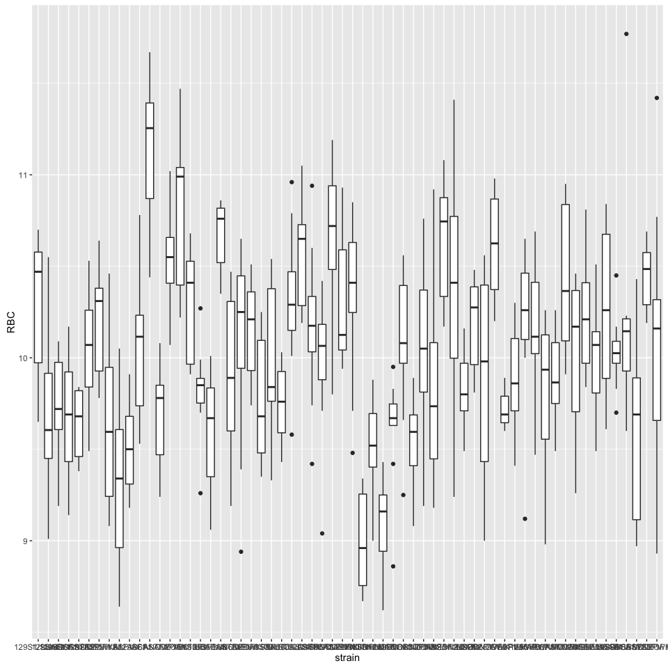

```r
ggplot(data = cc_data, mapping = aes(x = strain, y = RBC)) +
  geom_boxplot()
```

In a boxplot, the upper whisker extends to the highest value within 1.5 * inter-quartile range (IQR, or distance between first and third quartiles) and the lower whisker extends to the lowest value within 1.5 * IQR of the hinge. Data beyond the end of the whiskers (outliers) are plotted as points.

It’s difficult to distinguish the strain names on the x-axis, so flip the coordinates to place strain on the y-axis and red blood cells on the x-axis.

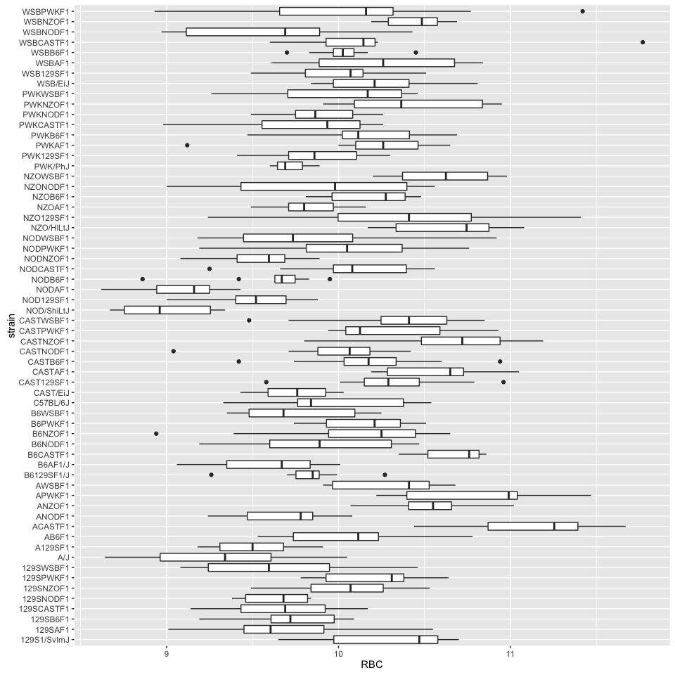

```r
ggplot(data = cc_data, mapping = aes(x = strain, y = RBC)) +
  geom_boxplot() +
  coord_flip()
```

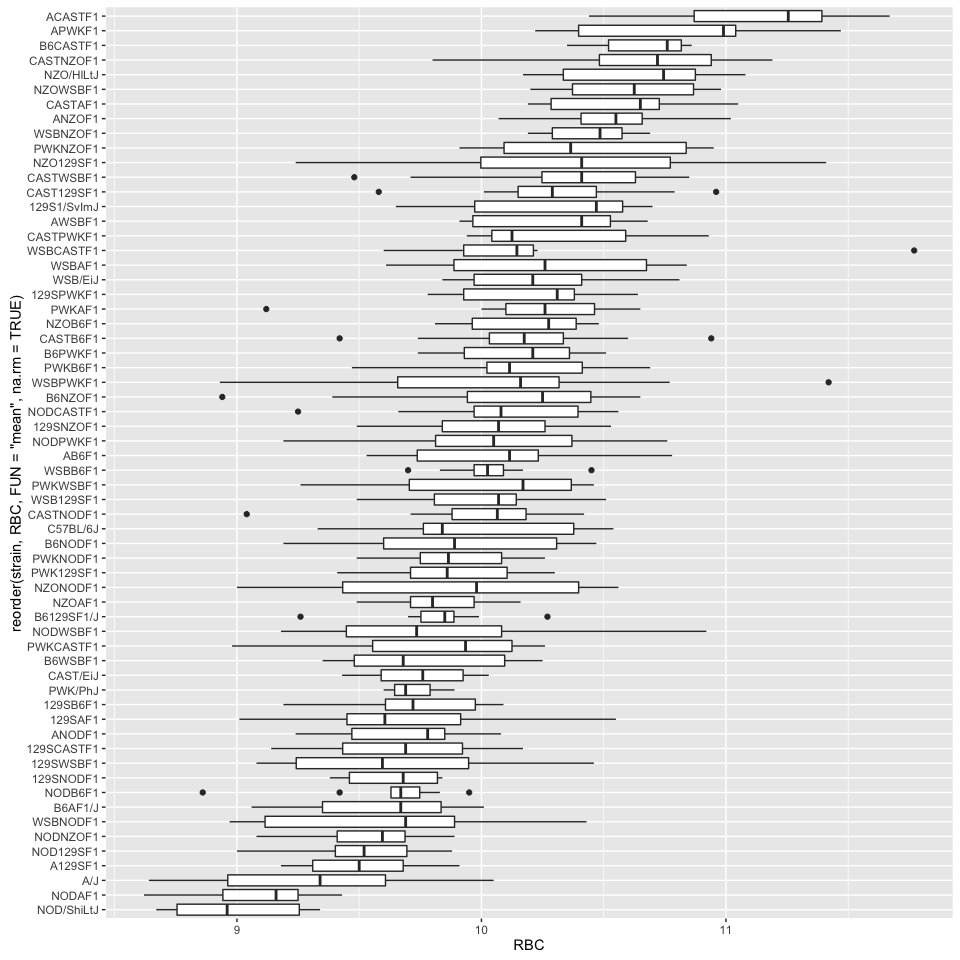

```r
ggplot(data = cc_data, mapping = aes(x = reorder(strain, RBC, FUN = "mean", na.rm = TRUE), y = RBC)) +
  geom_boxplot() +
  coord_flip()
```

Add a point indicating the mean RBC value for each strain. Add a statistical summary layer to do this. Specify the color, shape and size of the point marking the mean.

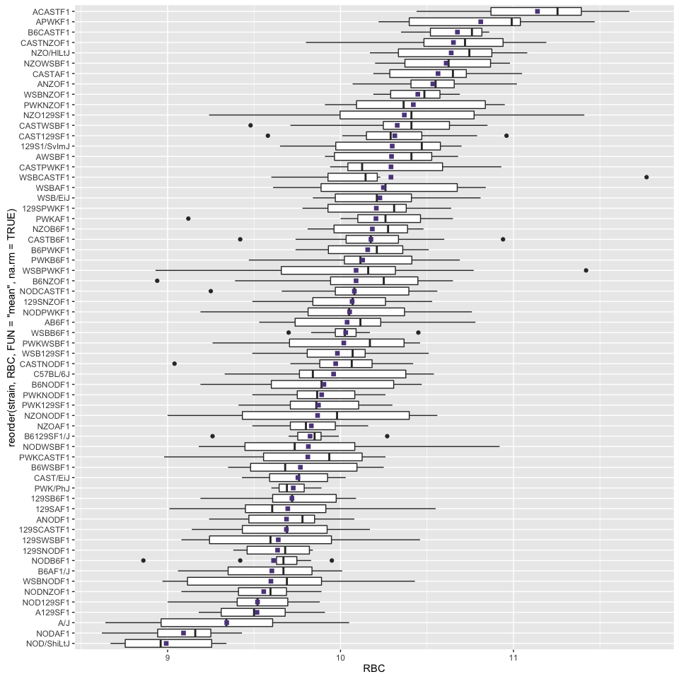

```r
ggplot(data = cc_data, mapping = aes(x = reorder(strain, RBC, FUN = "mean", na.rm = TRUE), y = RBC)) +
  geom_boxplot() +
  coord_flip() +
  stat_summary(fun.y = "mean", geom = "point", colour = "mediumpurple4", shape = 15, size = 2)
```

You should see a purple square indicating the mean red blood cell value for each strain. Is it the same as the median value for each strain? Notice that the mean value is sensitive to outliers, while the median value is not sensitive to outliers. Find the boxplot for WSBCASTF1. Notice that a single data point with a value greater than 11.5 pulls the mean value for this strain far over to the right.

Plot the data points over each boxplot. Since ggplot builds a plot layer by layer, the boxplot layer should come before the data points so as not to obscure them.

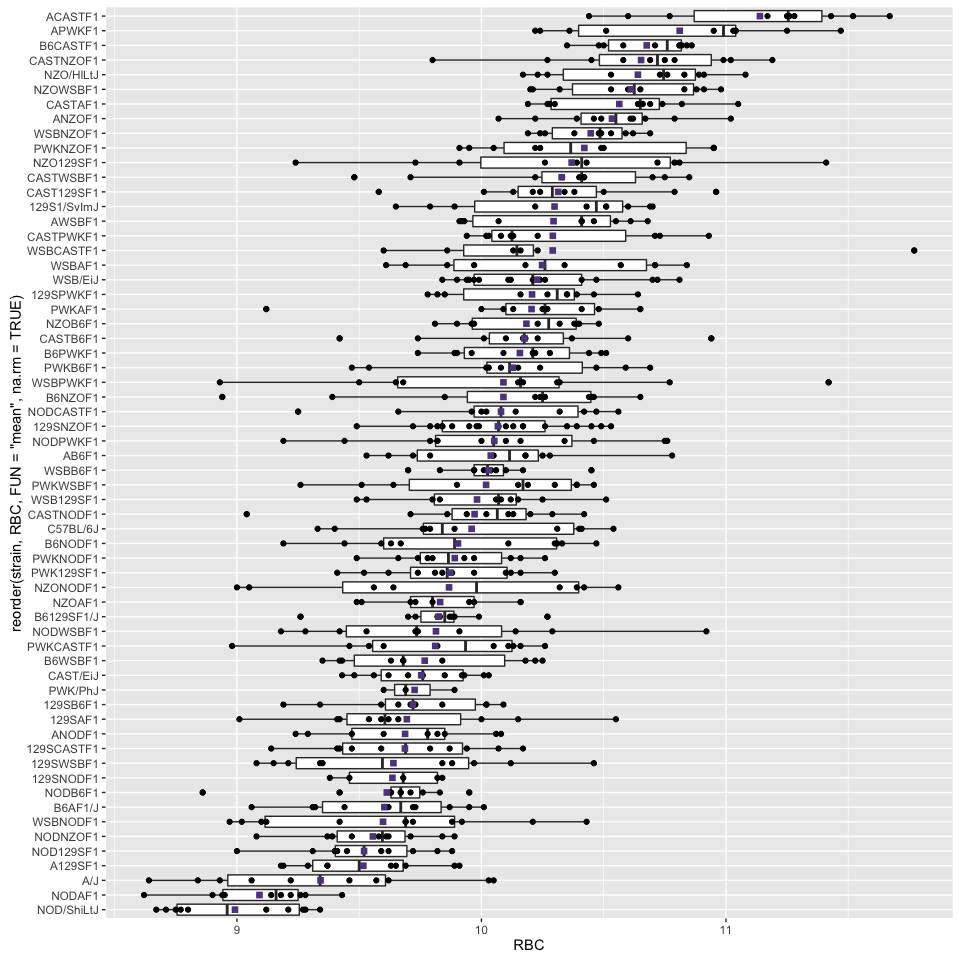

```r
ggplot(data = cc_data, mapping = aes(x = reorder(strain, RBC, FUN = "mean", na.rm = TRUE), y = RBC)) +
  geom_boxplot() +
  geom_point() +
  coord_flip() +
  stat_summary(fun.y = "mean", geom = "point", colour = "mediumpurple4", shape = 15, size = 2)
```

Color the data points by sex. Save the plot as a variable. To view the plot, type the name of the variable.

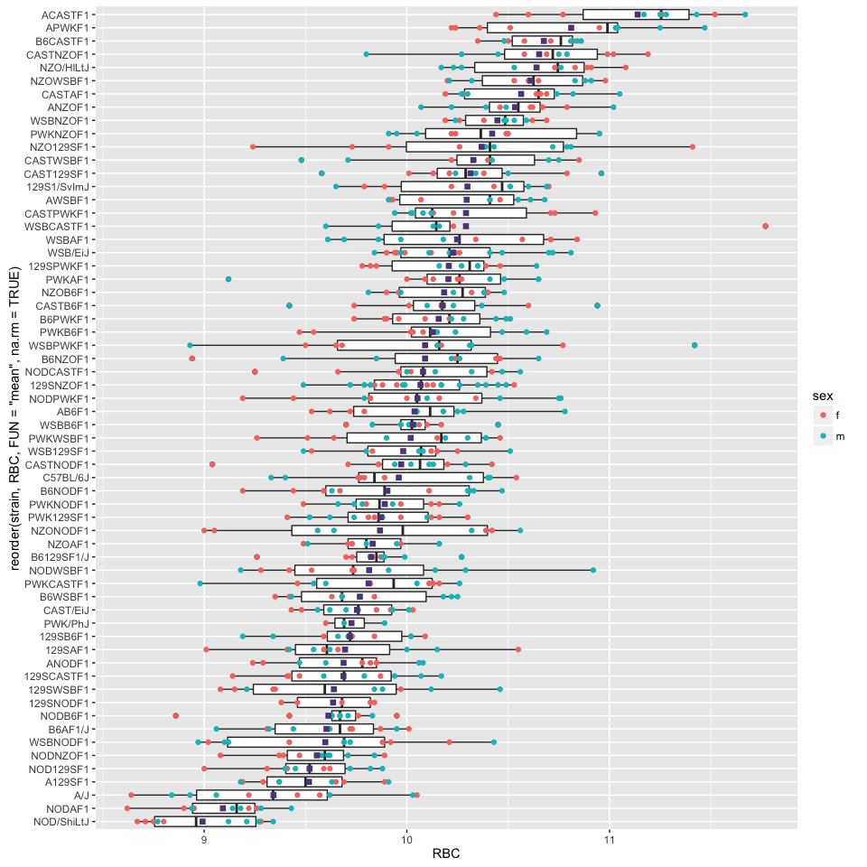

```r
rbc_boxplot <- ggplot(data = cc_data, mapping = aes(x = reorder(strain, RBC, FUN = "mean", na.rm = TRUE),
                                                    y = RBC)) +
  geom_boxplot() +
  geom_point(aes(colour = sex)) +
  coord_flip() +
  stat_summary(fun.y = "mean", geom = "point", colour = "mediumpurple4", shape = 15, size = 2)
rbc_boxplot
```

Add axis labels. Redefine the plot variable.

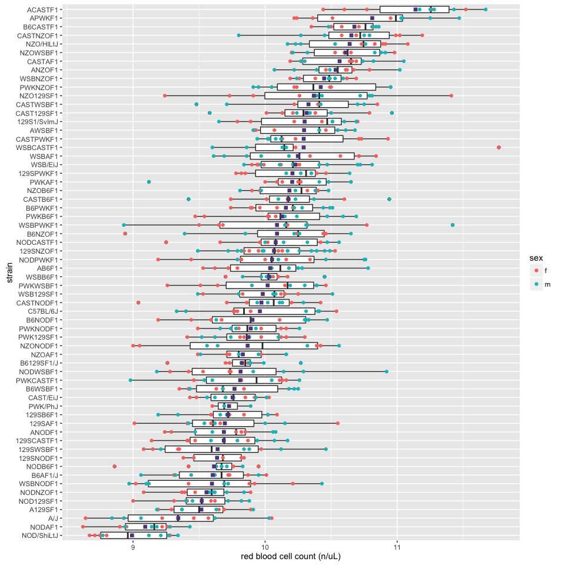

```r
rbc_boxplot <- rbc_boxplot +
  xlab("strain") +
  ylab("red blood cell count (n/uL)")
rbc_boxplot
```

Add a title. Redefine the plot variable.

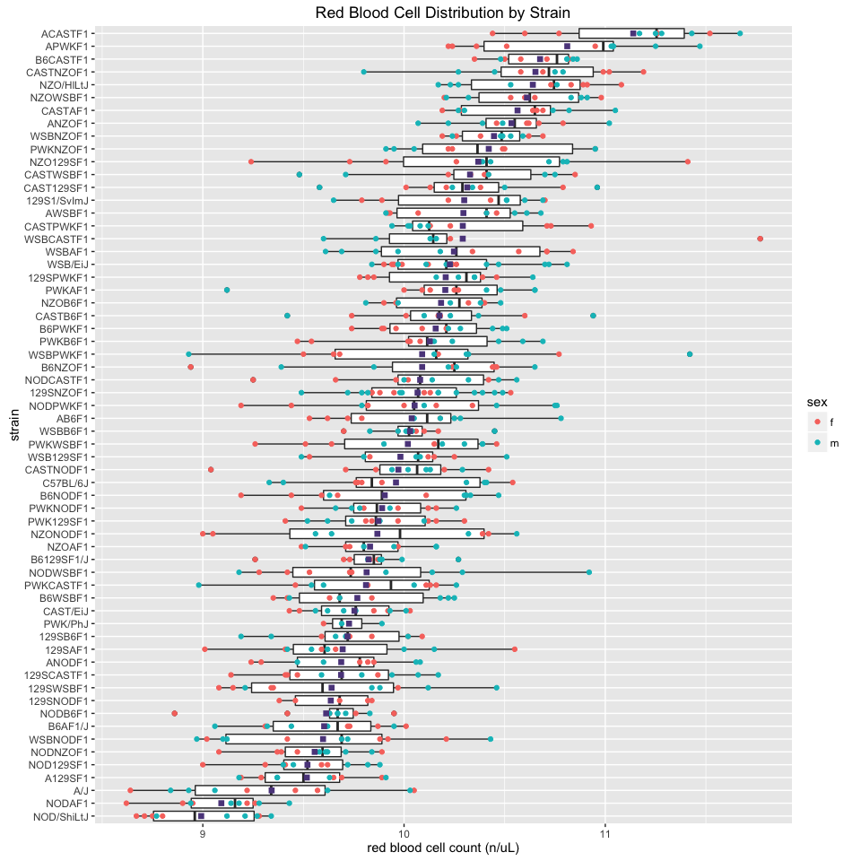

```r
rbc_boxplot <- rbc_boxplot +
  ggtitle("Red Blood Cell Distribution by Strain")
rbc_boxplot
```

#### Subsetting data

Select a subset of the strains. Choose strains with the highest and lowest mean and median red blood cell counts. Include the parent strains of the F1s.

```r
subset.cc_data <- subset(cc_data, strain %in% c("ACASTF1", "APWKF1", "CAST/EiJ", "PWK/PhJ",
                                      "A/J", "NODAF1", "NOD/ShiLtJ") == TRUE)
```

Create boxplots from the subset.

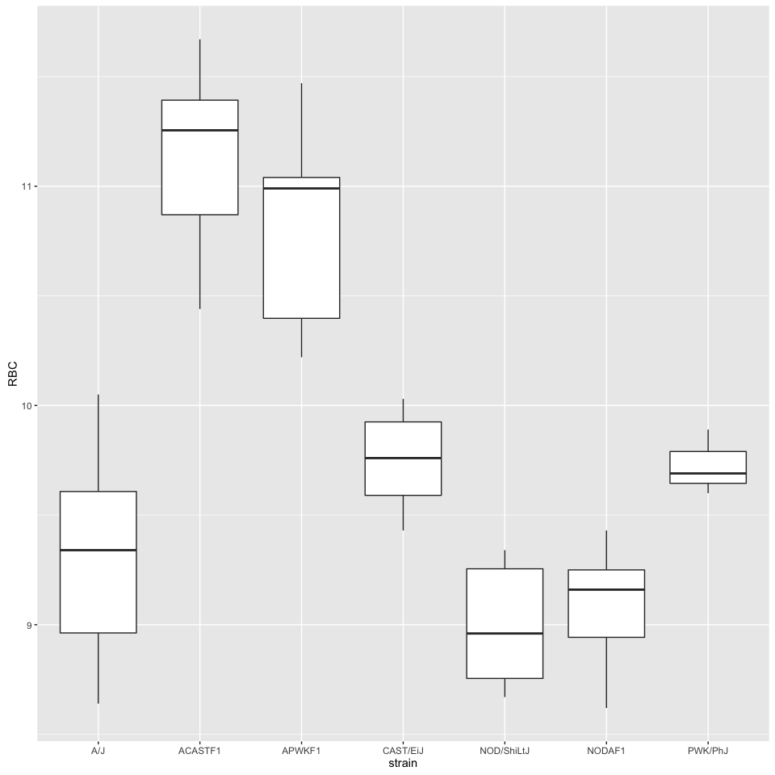

```r
ggplot(data = subset.cc_data, mapping = aes(x = strain, y = RBC)) +
  geom_boxplot()
```

Order by mean RBC value as before. Save the plot as a variable.

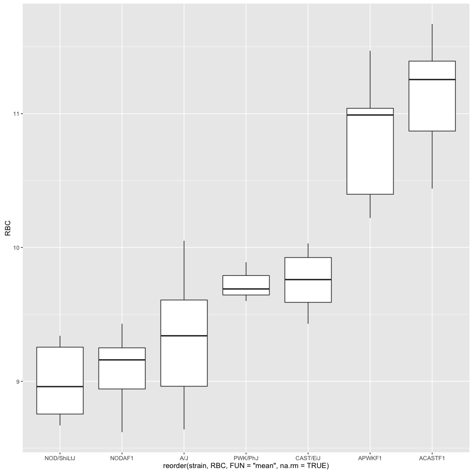

```r
subset_boxplot <- ggplot(data = subset.cc_data,
                         mapping = aes(x = reorder(strain, RBC, FUN = "mean", na.rm = TRUE),
                                       y = RBC)) +
  geom_boxplot()
subset_boxplot
```

This time there’s no need to flip the axes since the strain names are legible on the x-axis. Plot the data points by sex.The boxplots have already been drawn and saved in the variable subset_boxplot. Layer the data points on top of the boxplots.

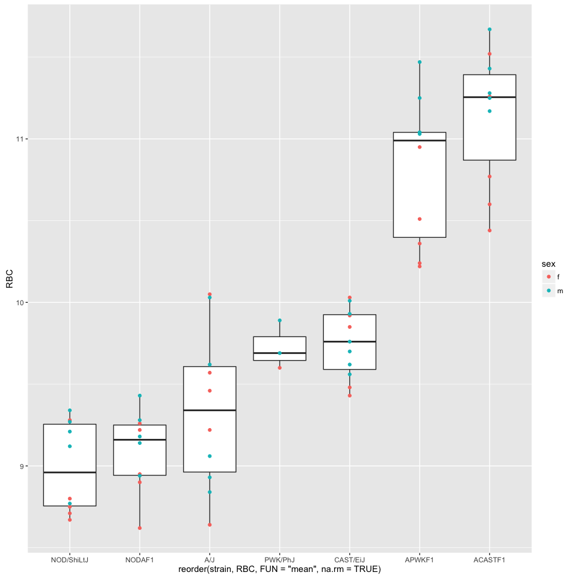

```r
subset_boxplot <- subset_boxplot +
  geom_point(aes(colour = sex))
subset_boxplot
```

Add a purple square indicating the mean RBC value for each strain.

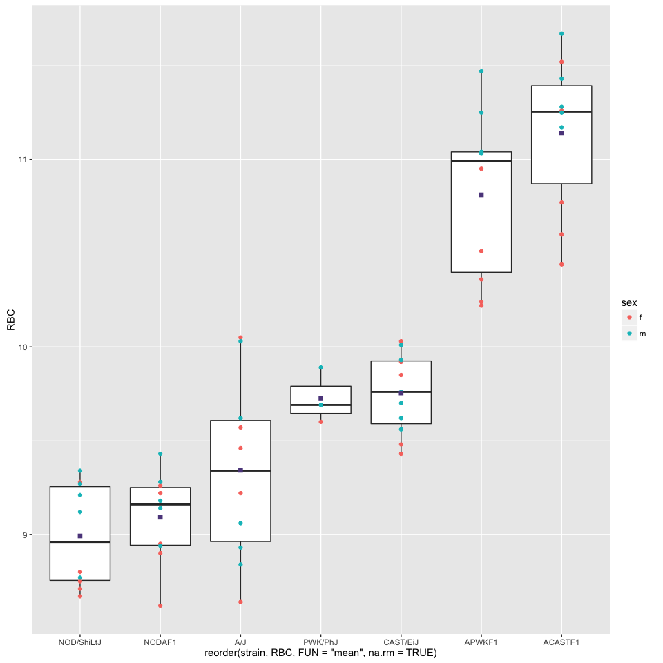

```r
subset_boxplot <- subset_boxplot +
  stat_summary(fun.y = "mean", geom = "point", colour = "mediumpurple4", shape = 15, size = 2)
subset_boxplot
```

Add x and y axis labels.

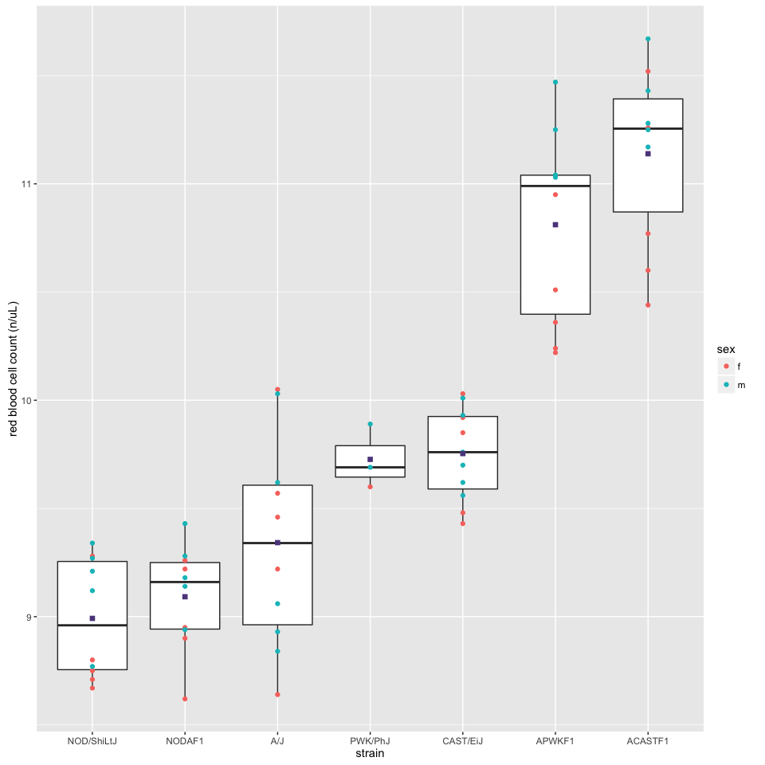

```r
subset_boxplot <- subset_boxplot +
  xlab("strain") +
  ylab("red blood cell count (n/uL)")
subset_boxplot
```

Add a title.

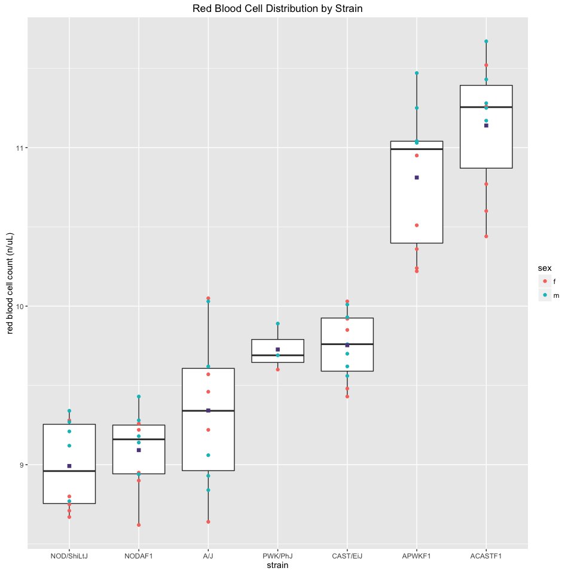

```r
subset_boxplot <- subset_boxplot +
  ggtitle("Red Blood Cell Distribution by Strain")
subset_boxplot
```

Output the plot to a PDF file. Set width and height. Turn off the output to pdf with the dev.off() command.

```r
pdf("subset-boxplot.pdf", width= 8, height = 9)
print(subset_boxplot)
dev.off()
```

Picture a set of bar charts indicating the mean and s.e.m. for each strain. Which plot communicates more information, a bar chart or a box plot?

> Code Challenge: Choose another phenotype to plot as boxplots by strain. Order boxplots by mean phenotype value. Flip the coordinates if necessary to make strain names legible. Add a point indicating the mean strain value. Add data points over the boxplots. Add axis labels and a plot title.

## References

1. Kick the bar chart habit. Nat Meth. 2014;11(2):113. doi: 10.1038/nmeth.2837.
2. Lenarcic AB, Svenson KL, Churchill GA, Valdar W. A general Bayesian approach to analyzing diallel crosses of inbred strains. Genetics. 2012 Feb 1;190(2):413-35.
3. Spitzer M, Wildenhain J, Rappsilber J, Tyers M. BoxPlotR: a web tool for generation of box plots. Nat Meth. 2014;11(2):121-2. doi: 10.1038/nmeth.2811.
4. Krzywinski M, Altman N. Points of Significance: Visualizing samples with box plots. Nat Meth. 2014;11(2):119-20. doi: 10.1038/nmeth.2813.